# Assignment 7 - BN

MSDS 5213, Lipscomb University

### 1 Bayesian Network: Example

For this example we will use the bnlearn package in R to illustrate the use of Bayesian Network. We will use R to create the network illustrated by the figure below.

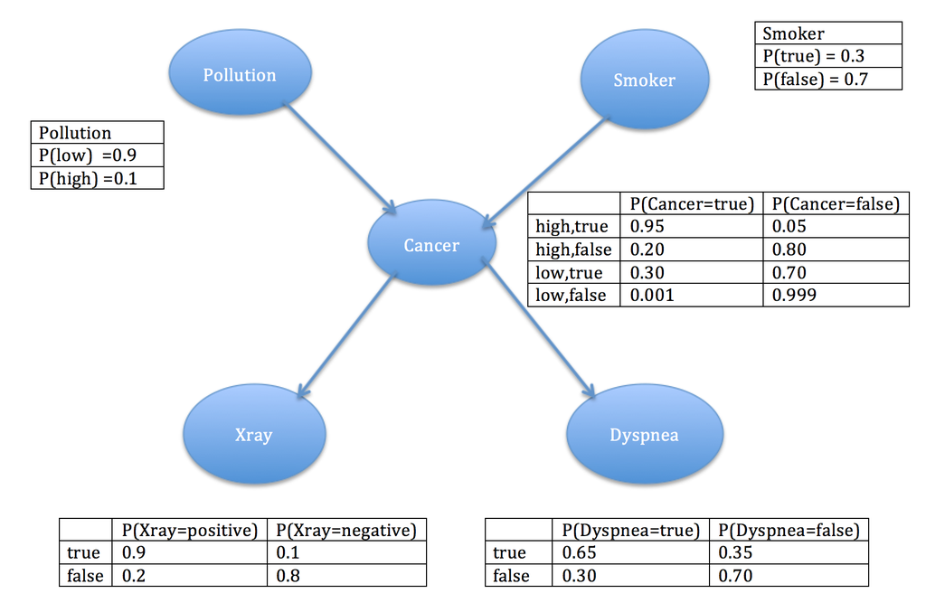

Start by loading the bnlearn library

```r
library(bnlearn)
```

Create the names of the nodes for the network

```r
vname = c("Pol","Smk","Can","Xry","Dys")
```

Attach the nodes to a graph

```r
e = empty.graph(vname)
```

Create the connection(relation) between the nodes. Then, attach the connection to the graph

```r
arc.set = matrix(c("Pol","Smk","Can","Can","Can","Can","Xry","Dys"),
ncol = 2, dimnames = list (NULL,c("from","to")))
arcs(e) = arc.set
```

Create the conditional probability tables for each node

```r
cptPol = matrix(c(0.9,0.1), ncol = 2, dimnames = list(NULL, c("low","high")))
cptSmk = matrix(c(0.3,0.7), ncol = 2, dimnames = list(NULL, c("true","false")))
cptCan = c(0.30,0.70,0.001,0.999,0.95,0.05,0.2,0.8)
dim(cptCan) = c(2,2,2)
dimnames(cptCan) = list("Can" = c("true","false"),"Smk" = c("true","false"),"Pol" = c("low","high"))
cptXry = c(0.9,0.1,0.2,0.8)
dim(cptXry) = c(2,2)
dimnames(cptXry) = list("Xry" = c("true","false"), "Can" = c("true","false"))
cptDys = c(0.65,0.35,0.3,0.7)
dim(cptDys) = c(2,2)
dimnames(cptDys) = list("Dys" = c("true","false"), "Can" = c("true","false"))
```

Attach the CPTs to the graph.

```r
dfit = custom.fit(e, dist = list(Pol = cptPol, Smk = cptSmk, Can = cptCan, Xry= cptXry, Dys = cptDys))
dfit
```

```
##
##   Bayesian network parameters
##
##   Parameters of node Pol (multinomial distribution)
##
## Conditional probability table:
##
##  low high
##  0.9  0.1
##
##   Parameters of node Smk (multinomial distribution)
##
## Conditional probability table:
##
##  true false
##   0.3   0.7
##
##   Parameters of node Can (multinomial distribution)
##
## Conditional probability table:
##
## , , Smk = true
##
##        Pol
## Can       low  high
##   true  0.300 0.950
##   false 0.700 0.050
##
## , , Smk = false
##
##        Pol
## Can       low  high
##   true  0.001 0.200
##   false 0.999 0.800
##
##
##   Parameters of node Xry (multinomial distribution)
##
## Conditional probability table:
##
##        Can
## Xry     true false
##   true   0.9   0.2
##   false  0.1   0.8
##
##   Parameters of node Dys (multinomial distribution)
##
## Conditional probability table:
##
##        Can
## Dys     true false
##   true  0.65  0.30
##   false 0.35  0.70
```

Now we are ready to query the network. The R code below are calculating the following probabilities:

- P(Polution = low|Cancer = true)
- P(Polution = low|Cancer = true;Dysponea = false)
- P(Xray = positive|Cancer = true;Dysponea = false)
- P(Xray = negative|Cancer = true;Dysponea = false)
- P(Xray = negative|Polution = high; Smoker = true)
- P(Xray = positive|Polution = high; Smoker = true)

```r
cpquery(dfit,event=(Pol == "low"), evidence=(Can == "true"))
```

```
## [1] 0.624183
```

```r
cpquery(dfit,event=(Pol == "low"), evidence=(Can == "true") & (Dys=="false"))
```

```
## [1] 0.6585366
```

```r
cpquery(dfit,event=(Xry == "true"), evidence=(Can == "true") & (Dys=="false"))
```

```
## [1] 0.9281768
```

```r
cpquery(dfit,event=(Xry == "false"), evidence=(Can == "true") & (Dys=="false"))
```

```
## [1] 0.09852217
```

```r
cpquery(dfit,event=(Xry == "false"), evidence=(Pol == "high") & (Smk=="true"))
```

```
## [1] 0.106383
```

```r
cpquery(dfit,event=(Xry == "true"), evidence=(Pol == "high") & (Smk=="true"))
```

```
## [1] 0.8830409
```

### 2 Homework

For the homework, you will use the bnlearn library and R to create bayesian network described by the figure below.

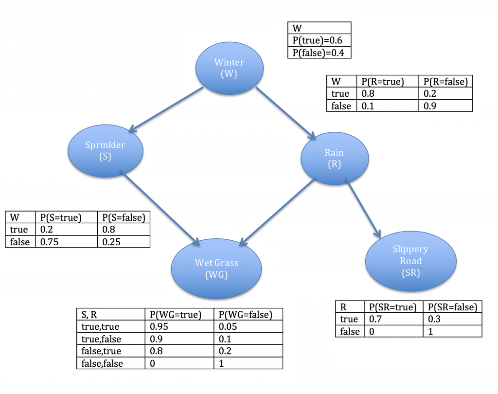

### Your tasks

1. Submit the list of command you have used to create the network, make sure your CPT tables are correct.
2. Calculate the following probabilities
- P(SR = false|W = true)
- P(WG = true|S = true;W = true)
- P(SR = true|WG = true; S = false)
- P(WG = false|SR = false;W = true)
3. submit a list of the commands you have used to answer the above probabilities calculation along with the results of the commands

### 3 Sources

- https://cran.r-project.org/web/packages/bnlearn/bnlearn.pdf